# 2. Regression and model validation

*Below are all the codes, my interpretations and explanations for this week’s data analysis exercises.*

*A brief note about data wrangling that preceded this diary entry. After I filtered my dataset to exclude rows that had zero values for points, almost the whole dataset printed NA values. I found the following solution in StackOverflow:*

a_dataset <- analysis_dataset[apply(analysis_dataset!=0, 1, all),]

*I now have the correct number of observations and variables, but this method would exclude all other zero rows too I think…*

To read the previously wrangled data from my local folder into R:

```r
mydata <- read.csv("learning2014.csv")
```

The dataset is a combination of certain variables from a survey dataset. The survey examined the relationship between learning approaches and the achievements of students. All combination variables were scaled to the original scales. Observations where the exam points variable is zero (student did not sit the exam) were excluded to remove outliers. The (combination) variables included are:  
- gender  
- age  
- attitude (Global attitude toward statistics)  
- deep (measures deep learning)  
- stra (measures strategic learning)  
- surf (measures surface learning)  
- points (points from the exam)

To begin the graphical overview of the data,I initialized the plot with data and aesthetic mappings, including colours by the variable gender, and showed summaries of the variables in the data:

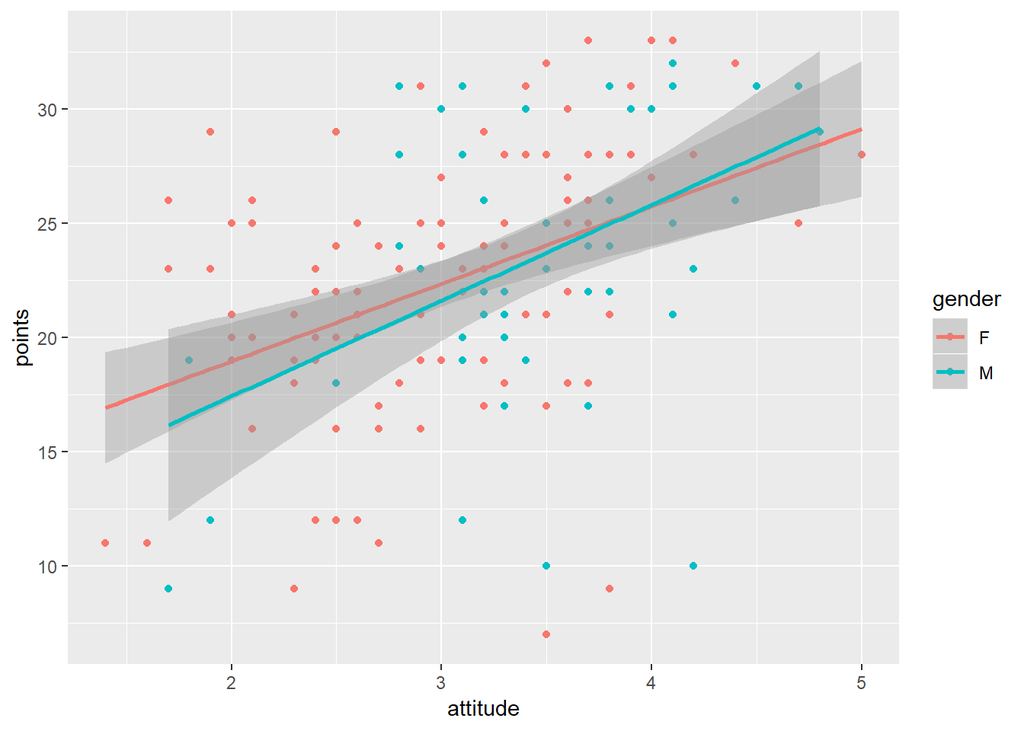

```r
library(ggplot2)
p1 <- ggplot(mydata, aes(x = attitude, y = points, col = gender))
p2 <- p1 + geom_point()
p3 <- p2 + geom_smooth(method = "lm")
p3
```

Summary of the data is presented below.

```r
summary(mydata)
```

```
##        X          gender       age           attitude          deep
##  Min.   :  1.00   F:110   Min.   :17.00   Min.   :1.400   Min.   :1.583
##  1st Qu.: 44.25   M: 56   1st Qu.:21.00   1st Qu.:2.600   1st Qu.:3.333
##  Median : 87.50           Median :22.00   Median :3.200   Median :3.667
##  Mean   : 90.13           Mean   :25.51   Mean   :3.143   Mean   :3.680
##  3rd Qu.:136.75           3rd Qu.:27.00   3rd Qu.:3.700   3rd Qu.:4.083
##  Max.   :183.00           Max.   :55.00   Max.   :5.000   Max.   :4.917
##
##       stra            surf           points           X.1
##  Min.   :1.250   Min.   :1.583   Min.   : 7.00   Min.   :22.72
##  1st Qu.:2.625   1st Qu.:2.417   1st Qu.:19.00   1st Qu.:22.72
##  Median :3.188   Median :2.833   Median :23.00   Median :22.72
##  Mean   :3.121   Mean   :2.787   Mean   :22.72   Mean   :22.72
##  3rd Qu.:3.625   3rd Qu.:3.167   3rd Qu.:27.75   3rd Qu.:22.72
##  Max.   :5.000   Max.   :4.333   Max.   :33.00   Max.   :22.72
##                                                  NA's   :165
##       X.2
##  Min.   :11.36
##  1st Qu.:11.36
##  Median :11.36
##  Mean   :11.36
##  3rd Qu.:11.36
##  Max.   :11.36
##  NA's   :165
```

The gender split of the respondents was 110 female and 56 male. Their ages ranged from 17 to 55, with an average age 25.51. The variable “attitude” is a combination variable of 10 variables and measures a global attitude toward statistics. The next three variables, deep approach (deep), strategic approach (stra) and surface approach (surf) are likewise combinatory variables and they have been scaled to the original scales. The average of attitude is 3.143, deep 3.68, strategic 3.121 and surface 2.787. The variable points shows the number of points the student achieved in an exam, and the average was 22.72.

For my model I chose the variables `age`, `attitude` and `stra` as explanatory variables and the target variable is points. A summary of the fitted model is shown below.

```r
my_model <- lm(points ~ age + attitude + stra, data = mydata)
summary(my_model)
```

```
##
## Call:
## lm(formula = points ~ age + attitude + stra, data = mydata)
##
## Residuals:
##      Min       1Q   Median       3Q      Max
## -18.1149  -3.2003   0.3303   3.4129  10.7599
##
## Coefficients:
##             Estimate Std. Error t value Pr(>|t|)
## (Intercept) 10.89543    2.64834   4.114 6.17e-05 ***
## age         -0.08822    0.05302  -1.664   0.0981 .
## attitude     3.48077    0.56220   6.191 4.72e-09 ***
## stra         1.00371    0.53434   1.878   0.0621 .
## ---
## Signif. codes:  0 '***' 0.001 '**' 0.01 '*' 0.05 '.' 0.1 ' ' 1
##
## Residual standard error: 5.26 on 162 degrees of freedom
## Multiple R-squared:  0.2182, Adjusted R-squared:  0.2037
## F-statistic: 15.07 on 3 and 162 DF,  p-value: 1.07e-08
```

The p-values for the coefficients indicate whether these relationships are statistically significant. The model above shows the variables with their significance levels. Age and strategic have a significance level of approximately 0.1 and 0.06 respectively, which, while being larger than the more or less generally accepted level of 0.05, still shows some significance. However, as keeping variables that are not statistically very significant can reduce the model’s precision, I will therefore only include `attitude` (with its significance code of 0) and `stra` (with the significance level that is very close to 0.05) in my re-fitted model. The new model is shown below.

```r
my_model <- lm(points ~ attitude + stra, data = mydata)
summary(my_model)
```

```
##
## Call:
## lm(formula = points ~ attitude + stra, data = mydata)
##
## Residuals:
##      Min       1Q   Median       3Q      Max
## -17.6436  -3.3113   0.5575   3.7928  10.9295
##
## Coefficients:
##             Estimate Std. Error t value Pr(>|t|)
## (Intercept)   8.9729     2.3959   3.745  0.00025 ***
## attitude      3.4658     0.5652   6.132 6.31e-09 ***
## stra          0.9137     0.5345   1.709  0.08927 .
## ---
## Signif. codes:  0 '***' 0.001 '**' 0.01 '*' 0.05 '.' 0.1 ' ' 1
##
## Residual standard error: 5.289 on 163 degrees of freedom
## Multiple R-squared:  0.2048, Adjusted R-squared:  0.1951
## F-statistic: 20.99 on 2 and 163 DF,  p-value: 7.734e-09
```

The multiple regression model makes the following assumptions:  
1. The relationship between the independent and dependent variables is linear.  
2. The errors between observed and predicted values should be normally distributed.  
3. The data has no multicollinearity (this happens when the independent variables correlate too highly with each other).  
4. Homoscedasticity, a.k.a. homogeneity of variance.

The validity of these model assumptions can be explored by analyzing the residuals of the model, as in the plots shown below.

To produce the diagnostic plots Residuals vs Fitted values (plot 1), Normal QQ-plot (plot 2) and Residuals vs Leverage (plot 5):

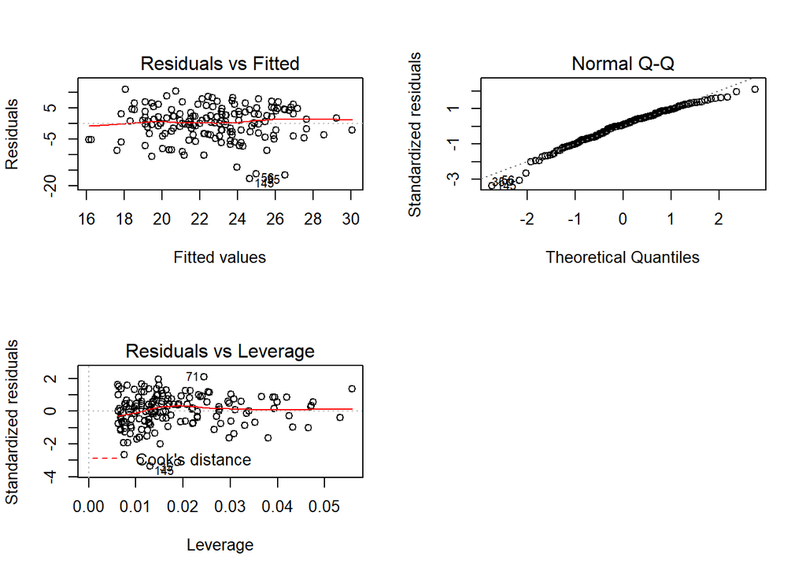

```r
par(mfrow = c(2,2))
plot(my_model, which = c(1:2, 5))
```

The normality assumption (assumption 2. above) can be explored by analyzing the Q-Q plot. The fit to the normality assumption is reasonably good in this case.

The homoscedasticity assumption (assumption 4.) implies that the size of the errors should not depend on the explanatory variables. This can be explored with the residuals vs fitted plot. As we can see from the first plot, there is a reasonably random placement of plots with no discernible pattern, and therefore the assumption is valid.

After this graphical exploration we can conclude that the validity of the model assumptions is good.